# Group A — Yogurt Study: Data Dictionary

Understanding every column in the four CSV files

## Overview

This document describes the four CSV files in `data/group_a_yogurt/`. This is a study about **how eating yogurt affects the vaginal microbiome**, specifically after a course of antibiotics.

**Study design in a nutshell:** Participants provided samples at two time points — a baseline visit and a visit after taking antibiotics. Participants were split into two arms: one group ate yogurt during the study, the other group kept their usual diet (no yogurt). Researchers then measured the types and amounts of bacteria present (via qPCR) and the levels of immune-signalling proteins called **cytokines** (via Luminex).

```r
library(dplyr)
library(ggplot2)
library(tidyr)
library(readr)
library(here)

data_dir <- here("data", "group_a_yogurt")
```

## File 1: `00_sample_ids_yogurt.csv`

> **What one row represents:** A single sample collected from one participant at one time point.

```r
samples <- read_csv(file.path(data_dir, "00_sample_ids_yogurt.csv"))
glimpse(samples)
```

```
Rows: 102
Columns: 4
$ pid        <chr> "pid_25", "pid_51", "pid_33", "pid_13", "pid_37", "pid_09",…
$ time_point <chr> "baseline", "baseline", "baseline", "baseline", "after_anti…
$ arm        <chr> "unchanged_diet", "yogurt", "yogurt", "yogurt", "unchanged_…
$ sample_id  <chr> "UNCH001", "YOG002", "YOG003", "YOG004", "UNCH005", "UNCH00…
```

### Columns

| Column | Type | What it means | Possible values |
| --- | --- | --- | --- |
| `pid` | character | **Participant ID** — a code that identifies each person in the study. Each participant has two rows (baseline + after antibiotic). | `pid_01` through `pid_51` (51 unique people) |
| `time_point` | character | When the sample was taken. “baseline” = before antibiotics, “after_antibiotic” = after the antibiotic course. | `"baseline"`, `"after_antibiotic"` |
| `arm` | character | Which group the participant was assigned to. “yogurt” = ate yogurt, “unchanged_diet” = control group (no yogurt). | `"yogurt"`, `"unchanged_diet"` |
| `sample_id` | character | **Unique sample identifier.** Samples starting with `UNCH` are from the unchanged-diet (control) group; samples starting with `YOG` are from the yogurt group. | e.g. `"UNCH001"`, `"YOG002"` (102 unique values — one per row) |

### Summary

Every person (pid) appears **twice** here — once at baseline and once after antibiotics — because each person contributed two samples to the study.

```r
samples |>
  count(time_point) |>
  knitr::kable()
```

| time_point | n |
| --- | --- |
| after_antibiotic | 51 |
| baseline | 51 |

## File 2: `01_participant_metadata_yogurt.csv`

> **What one row represents:** Background information about **one participant**.

```r
metadata <- read_csv(file.path(data_dir, "01_participant_metadata_yogurt.csv"))
glimpse(metadata)
```

```
Rows: 51
Columns: 7
$ pid                 <chr> "pid_01", "pid_02", "pid_03", "pid_04", "pid_05", …
$ arm                 <chr> "unchanged_diet", "unchanged_diet", "unchanged_die…
$ days_since_last_sex <dbl> 2, 4, 3, 1, 5, 9, 3, 4, 10, 7, 9, 20, 1, 1, 11, 3,…
$ birth_control       <chr> "no hormonal birth control", "Depoprovera", "no ho…
$ age                 <dbl> 28, 34, 32, 30, 34, 27, 25, 26, 34, 32, 32, 32, 30…
$ education           <chr> "grade 10-12, not matriculated", "less than grade …
$ sex                 <chr> "female", "female", "female", "female", "female", …
```

### Columns

| Column | Type | What it means | Possible values |
| --- | --- | --- | --- |
| `pid` | character | Participant ID — matches the same IDs in `00_sample_ids_yogurt.csv`. | `pid_01` through `pid_51` |
| `arm` | character | Study arm the participant was assigned to (same as in the samples file). | `"yogurt"`, `"unchanged_diet"` |
| `days_since_last_sex` | double | Number of days since the participant last had sex before providing the sample. Important because sexual activity can temporarily change the vaginal microbiome. | 1–48 days |
| `birth_control` | character | Type of hormonal birth control the participant was using (or none). Hormonal contraception can affect the vaginal microbiome. | `"Depoprovera"` (an injectable), `"no hormonal birth control"` |
| `age` | double | Participant’s age in years. | 24–37 years old |
| `education` | character | Highest level of education completed, in 4 categories. | `"less than grade 9"`, `"grade 10-12, not matriculated"`, `"grade 10-12, matriculated"`, `"post-secondary"` |
| `sex` | character | Biological sex — all participants are female (this is a vaginal microbiome study). | `"female"` |

### Quick look at demographics by arm

This helps you check whether the two groups look similar (which is what you’d expect from random assignment).

```r
metadata |>
  group_by(arm) |>
  summarise(
    n             = n(),
    mean_age      = mean(age),
    mean_days_sex = mean(days_since_last_sex),
    depo_provera  = sum(birth_control == "Depoprovera"),
    .groups       = "drop"
  ) |>
  knitr::kable()
```

| arm | n | mean_age | mean_days_sex | depo_provera |
| --- | --- | --- | --- | --- |
| unchanged_diet | 25 | 30.44 | 7.44 | 8 |
| yogurt | 26 | 31.00 | 9.50 | 17 |

## File 3: `02_qpcr_results_yogurt.csv`

> **What one row represents:** qPCR (quantitative PCR) measurements of bacterial DNA from **one sample**.

qPCR is a lab technique that measures how much of a specific DNA target is present. Here they used it to count **total bacteria** and two specific species of *Lactobacillus* that are important for vaginal health.

```r
qpcr <- read_csv(file.path(data_dir, "02_qpcr_results_yogurt.csv"))
glimpse(qpcr)
```

```
Rows: 102
Columns: 4
$ sample_id      <chr> "UNCH092", "UNCH042", "UNCH015", "UNCH035", "UNCH019", …
$ qpcr_bacteria  <dbl> 3093064.20, 8275.04, 7532202.40, 4794320.40, 5328343.60…
$ qpcr_crispatus <dbl> 0.000, 0.000, 0.000, 12.994, 0.000, 0.000, 0.000, 38.58…
$ qpcr_iners     <dbl> 26.840, 76.040, 554.964, 204308.968, 107806.148, 121045…
```

### Columns

| Column | Type | What it means | Notes |
| --- | --- | --- | --- |
| `sample_id` | character | Which sample these measurements come from — matches `00_sample_ids_yogurt.csv`. | 102 unique values |
| `qpcr_bacteria` | double | **Total bacterial load** — the amount of DNA from all bacteria combined in the sample. Measured in gene-copy equivalents (a proxy for number of bacteria). | Large numbers (thousands to millions) |
| `qpcr_crispatus` | double | Amount of *Lactobacillus crispatus* DNA. *L. crispatus* is considered a “good” bacterium that helps keep the vagina healthy. | Many values are 0 (not detected) |
| `qpcr_iners` | double | Amount of *Lactobacillus iners* DNA. *L. iners* is another common species — it’s less protective than *L. crispatus* and is associated with a less stable microbiome. | Large variation across samples |

### A peek at the bacterial data

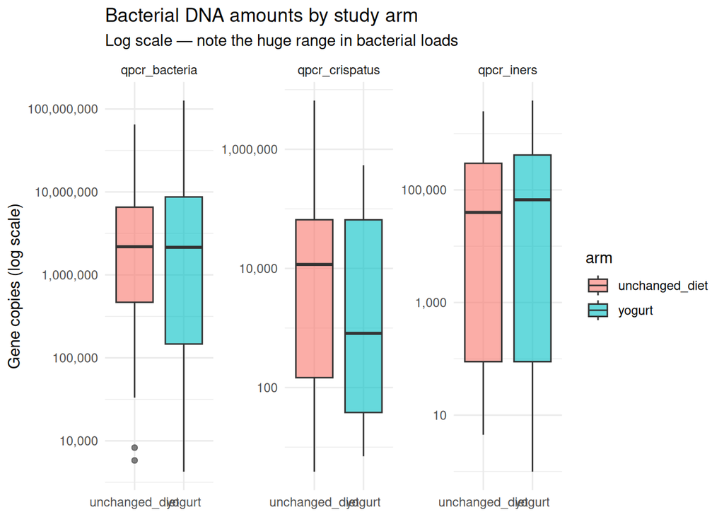

```r
# Join with participant info so we can compare groups
samples |>
  inner_join(qpcr, by = "sample_id") |>
  pivot_longer(c(qpcr_bacteria, qpcr_crispatus, qpcr_iners),
               names_to  = "target",
               values_to = "copies") |>
  ggplot(aes(x = arm, y = copies, fill = arm)) +
  geom_boxplot(alpha = 0.6) +
  facet_wrap(~ target, scales = "free_y") +
  scale_y_log10(labels = scales::label_comma()) +
  labs(
    title    = "Bacterial DNA amounts by study arm",
    subtitle = "Log scale — note the huge range in bacterial loads",
    y        = "Gene copies (log scale)",
    x        = NULL
  ) +
  theme_minimal()
```

## File 4: `03_luminex_results_yogurt.csv`

> **What one row represents:** The concentration of **one cytokine** measured in **one sample**.

Cytokines are small proteins that cells use to signal to each other — they are key players in the immune system. Measuring them tells us about the level of inflammation or immune activity in the sample.

```r
luminex <- read_csv(file.path(data_dir, "03_luminex_results_yogurt.csv"))
glimpse(luminex)
```

```
Rows: 1,020
Columns: 4
$ sample_id <chr> "UNCH092", "UNCH092", "UNCH092", "UNCH092", "UNCH092", "UNCH…
$ cytokine  <chr> "IL-1a", "IL-10", "IL-1b", "IL-8", "IL-6", "TNFa", "IP-10", …
$ conc      <dbl> 5.8500, 0.7670, 0.2505, 7.9200, 0.0935, 0.4710, 177.3800, 36…
$ limits    <chr> "within limits", "out of range", "out of range", "within lim…
```

### Columns

[output not shown]

### The 10 cytokines measured

| Cytokine | Pro- or anti-inflammatory? | What it broadly signals |
| --- | --- | --- |
| **IL-1a** | Pro-inflammatory | Early response to infection / tissue damage |
| **IL-1b** | Pro-inflammatory | Fever, inflammation, immune cell activation |
| **IL-6** | Both | General inflammation signal |
| **IL-8** | Pro-inflammatory | Recruits immune cells to the site |
| **IL-10** | Anti-inflammatory | Calms down inflammation |
| **TNFa** | Pro-inflammatory | Major inflammation driver |
| **IFN-Y** | Pro-inflammatory | Activates immune cells (especially against viruses) |
| **IP-10** | Pro-inflammatory | Attracts immune cells to infected tissues |
| **MIG** | Pro-inflammatory | Similar to IP-10 — attracts immune cells |
| **MIP-3a** | Pro-inflammatory | Recruits immune cells to mucosal surfaces |

### How many samples had detectable levels?

```r
luminex |>
  group_by(cytokine) |>
  summarise(
    n_total       = n(),
    n_detected    = sum(limits == "within limits"),
    pct_detected  = mean(limits == "within limits") * 100
  ) |>
  arrange(-pct_detected) |>
  knitr::kable(digits = 1)
```

| cytokine | n_total | n_detected | pct_detected |
| --- | --- | --- | --- |
| IL-1a | 102 | 102 | 100.0 |
| IP-10 | 102 | 99 | 97.1 |
| IL-8 | 102 | 98 | 96.1 |
| MIG | 102 | 89 | 87.3 |
| MIP-3a | 102 | 78 | 76.5 |
| IL-1b | 102 | 28 | 27.5 |
| IL-6 | 102 | 25 | 24.5 |
| TNFa | 102 | 2 | 2.0 |
| IFN-Y | 102 | 1 | 1.0 |
| IL-10 | 102 | 0 | 0.0 |

### Cytokine levels by study arm

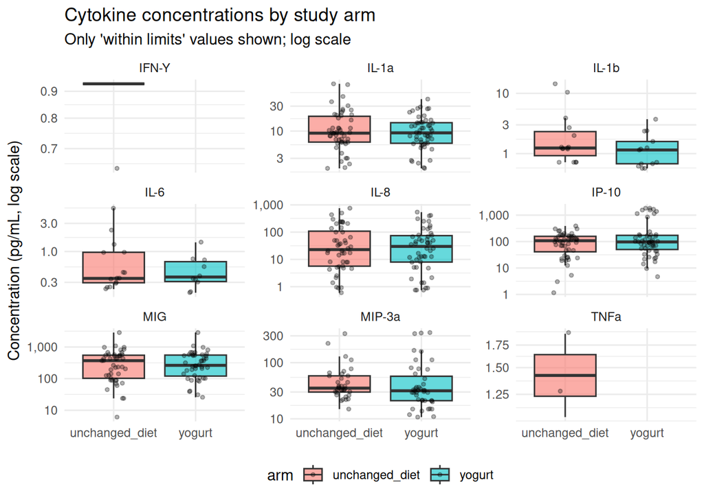

```r
samples |>
  inner_join(luminex, by = "sample_id") |>
  filter(limits == "within limits") |>
  ggplot(aes(x = arm, y = conc, fill = arm)) +
  geom_boxplot(alpha = 0.6, outlier.colour = NA) +
  geom_jitter(width = 0.15, alpha = 0.3, size = 1) +
  facet_wrap(~ cytokine, scales = "free_y") +
  scale_y_log10(labels = scales::label_comma()) +
  labs(
    title    = "Cytokine concentrations by study arm",
    subtitle = "Only 'within limits' values shown; log scale",
    y        = "Concentration (pg/mL, log scale)",
    x        = NULL
  ) +
  theme_minimal() +
  theme(legend.position = "bottom")
```

## How the four files connect

This is a **relational** dataset — the files link together through shared columns. Here’s the map:

```
01_participant_metadata_yogurt.csv     00_sample_ids_yogurt.csv
┌─────────────────────────────────┐    ┌─────────────────────────────┐
│ pid ──────────────────────────┐ │    │ pid ────────────────────────┤
│ arm                           │ │    │ sample_id ──────────────┐   │
│ days_since_last_sex           │ │    │ time_point               │   │
│ birth_control                 │ │    │ arm                      │   │
│ age                           │ │    └─────────────────────────┘   │
│ education                     │ │                 │               │
│ sex                           │ │                 │ pid           │
└─────────────────────────────────┘                 ▼               │
                                              ┌──────────────────┐   │
                                              │ 02_qpcr_results  │   │
                                              │ sample_id ───────┘   │
                                              │ qpcr_bacteria       │
                                              │ qpcr_crispatus      │
                                              │ qpcr_iners          │
                                              └─────────────────────┘
                                                │
                                                │ sample_id
                                                ▼
                                         ┌──────────────────────┐
                                         │ 03_luminex_results   │
                                         │ sample_id            │
                                         │ cytokine             │
                                         │ conc                 │
                                         │ limits               │
                                         └──────────────────────┘
```

**To join them in R:**

```r
# Combine everything into one analysis-ready table
full_data <- samples |>
  left_join(metadata, by = c("pid", "arm")) |>
  left_join(qpcr, by = "sample_id") |>
  left_join(luminex, by = "sample_id")

glimpse(full_data)
```

```
Rows: 1,020
Columns: 15
$ pid                 <chr> "pid_25", "pid_25", "pid_25", "pid_25", "pid_25", …
$ time_point          <chr> "baseline", "baseline", "baseline", "baseline", "b…
$ arm                 <chr> "unchanged_diet", "unchanged_diet", "unchanged_die…
$ sample_id           <chr> "UNCH001", "UNCH001", "UNCH001", "UNCH001", "UNCH0…
$ days_since_last_sex <dbl> 8, 8, 8, 8, 8, 8, 8, 8, 8, 8, 2, 2, 2, 2, 2, 2, 2,…
$ birth_control       <chr> "no hormonal birth control", "no hormonal birth co…
$ age                 <dbl> 27, 27, 27, 27, 27, 27, 27, 27, 27, 27, 36, 36, 36…
$ education           <chr> "grade 10-12, not matriculated", "grade 10-12, not…
$ sex                 <chr> "female", "female", "female", "female", "female", …
$ qpcr_bacteria       <dbl> 13493009, 13493009, 13493009, 13493009, 13493009, …
$ qpcr_crispatus      <dbl> 0, 0, 0, 0, 0, 0, 0, 0, 0, 0, 0, 0, 0, 0, 0, 0, 0,…
$ qpcr_iners          <dbl> 8.240, 8.240, 8.240, 8.240, 8.240, 8.240, 8.240, 8…
$ cytokine            <chr> "IL-1a", "IL-10", "IL-1b", "IL-8", "IL-6", "TNFa",…
$ conc                <dbl> 24.5500, 0.7670, 1.2800, 225.6100, 0.3500, 0.4710,…
$ limits              <chr> "within limits", "out of range", "within limits", …
```

## Quick reference: all columns at a glance

```r
knitr::kable(
  tibble(
    File = c(
      rep("00_sample_ids_yogurt.csv", 4),
      rep("01_participant_metadata_yogurt.csv", 7),
      rep("02_qpcr_results_yogurt.csv", 4),
      rep("03_luminex_results_yogurt.csv", 4)
    ),
    Column = c(
      "pid", "time_point", "arm", "sample_id",
      "pid", "arm", "days_since_last_sex", "birth_control",
      "age", "education", "sex",
      "sample_id", "qpcr_bacteria", "qpcr_crispatus", "qpcr_iners",
      "sample_id", "cytokine", "conc", "limits"
    ),
    Type = c(
      "character", "character", "character", "character",
      "character", "character", "double", "character",
      "double", "character", "character",
      "character", "double", "double", "double",
      "character", "character", "double", "character"
    ),
    `What it means` = c(
      "Participant ID (links to metadata)",
      "Baseline or after antibiotics",
      "Study group assignment",
      "Unique sample code (UNCH = control, YOG = yogurt)",
      "Participant ID (links to samples)",
      "Study group assignment",
      "Days since last sex",
      "Birth control type",
      "Age in years",
      "Education category",
      "Biological sex",
      "Unique sample code (links to samples)",
      "Total bacteria (gene copies)",
      "*L. crispatus* (gene copies)",
      "*L. iners* (gene copies)",
      "Unique sample code (links to samples)",
      "Cytokine measured",
      "Concentration (pg/mL)",
      "Within detection range?"
    )
  ),
  escape = FALSE
)
```

| File | Column | Type | What it means |
| --- | --- | --- | --- |
| 00_sample_ids_yogurt.csv | pid | character | Participant ID (links to metadata) |
| 00_sample_ids_yogurt.csv | time_point | character | Baseline or after antibiotics |
| 00_sample_ids_yogurt.csv | arm | character | Study group assignment |
| 00_sample_ids_yogurt.csv | sample_id | character | Unique sample code (UNCH = control, YOG = yogurt) |
| 01_participant_metadata_yogurt.csv | pid | character | Participant ID (links to samples) |
| 01_participant_metadata_yogurt.csv | arm | character | Study group assignment |
| 01_participant_metadata_yogurt.csv | days_since_last_sex | double | Days since last sex |
| 01_participant_metadata_yogurt.csv | birth_control | character | Birth control type |
| 01_participant_metadata_yogurt.csv | age | double | Age in years |
| 01_participant_metadata_yogurt.csv | education | character | Education category |
| 01_participant_metadata_yogurt.csv | sex | character | Biological sex |
| 02_qpcr_results_yogurt.csv | sample_id | character | Unique sample code (links to samples) |
| 02_qpcr_results_yogurt.csv | qpcr_bacteria | double | Total bacteria (gene copies) |
| 02_qpcr_results_yogurt.csv | qpcr_crispatus | double | *L. crispatus* (gene copies) |
| 02_qpcr_results_yogurt.csv | qpcr_iners | double | *L. iners* (gene copies) |
| 03_luminex_results_yogurt.csv | sample_id | character | Unique sample code (links to samples) |
| 03_luminex_results_yogurt.csv | cytokine | character | Cytokine measured |
| 03_luminex_results_yogurt.csv | conc | double | Concentration (pg/mL) |
| 03_luminex_results_yogurt.csv | limits | character | Within detection range? |